# jawlik_project

Matthew A Jawlik

Sunday, September 27, 2015

### Introduction

The objective of this project is to predict the type of movement being done (‘classe’ variable) given various measurements.

To answer this, I performed the following high-level steps:

1. Read in the data
2. To allow cross-validation, subdivide the training data into validation and train sets
3. Clean the data
4. Create two models, using 5-fold cross validation (Decision Tree and Random Forest)
5. Use confusion matrices to select the best
6. Apply to test dataset and submit

### Load the data:

Start by loading the necessary libraries and the two datasets.

```r
library(caret)
library(ggplot2)
library(dplyr)
library(rattle)
library(rpart)
library(randomForest)
library(rpart.plot)
library(knitr)
trainFile <- "C:\\Users\\MJawlik\\Documents\\R\\R-3.1.2\\Machine Learning\\Project\\pml-training.csv"
testFile <- "C:\\Users\\MJawlik\\Documents\\R\\R-3.1.2\\Machine Learning\\Project\\pml-testing.csv"
training <- data.frame(read.csv(trainFile, header=TRUE))
testing <- data.frame(read.csv(testFile, header=TRUE))
```

### Create a training and validation sets

For cross validation, we will split the training datset further into a train dataset and validation data set. 75% of the records will go into the train, and 25% reserved for cross validation.

```r
set.seed(39393)
inTrain <- createDataPartition(y=training$classe, p = 0.75, list = FALSE)
train <- training[inTrain, ]
validate <- training[-inTrain, ]
```

### Clean the Data

Clear near-zero variance variables & apply the same removal to validate and test sets

```r
nearZero <- nearZeroVar(train)
train <- train[, -nearZero]
validate <- validate[, -nearZero]
testing <- testing[, -nearZero]
```

```r
trainNoNA <- train[complete.cases(train), ]
dim(trainNoNA)
```

```
## [1] 299 105
```

```r
train <- train[, colSums(is.na(train)) == 0]
validate <- validate[, colSums(is.na(validate)) == 0]
```

X is not a real variable; removing

```r
train <- train[c(-1)]
validate <- validate[c(-1)]
testing <- testing[c(-1)]
```

### Create Models

#### Decision Tree

Train a model using the Decision Tree algorithm wth 5-fold cross-validation.

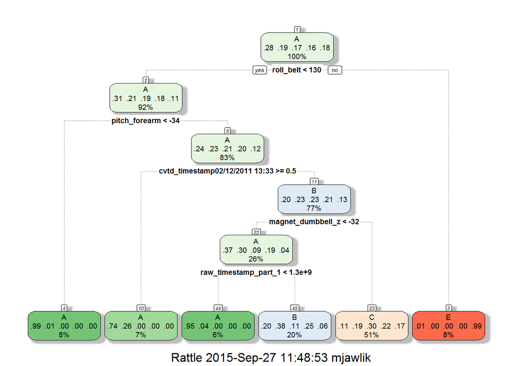

```r
tree <- train(classe ~ ., data=train, method="rpart",
               trControl=trainControl(method='cv', number=5))
fancyRpartPlot(tree$finalModel)
```

Predict on validation set

```r
predicted <- predict(tree, validate)
confusionMatrix(predicted, validate$classe)
```

```
## Confusion Matrix and Statistics
##
##           Reference
## Prediction   A   B   C   D   E
##          A 925  94   1   0   0
##          B 205 361 107 238  58
##          C 260 494 747 566 443
##          D   0   0   0   0   0
##          E   5   0   0   0 400
##
## Overall Statistics
##
##                Accuracy : 0.4961
##                  95% CI : (0.482, 0.5102)
##     No Information Rate : 0.2845
##     P-Value [Acc > NIR] : < 2.2e-16
##
##                   Kappa : 0.3687
##  Mcnemar's Test P-Value : NA
##
## Statistics by Class:
##
##                      Class: A Class: B Class: C Class: D Class: E
## Sensitivity            0.6631  0.38040   0.8737   0.0000  0.44395
## Specificity            0.9729  0.84627   0.5646   1.0000  0.99875
## Pos Pred Value         0.9069  0.37255   0.2976      NaN  0.98765
## Neg Pred Value         0.8790  0.85057   0.9549   0.8361  0.88864
## Prevalence             0.2845  0.19352   0.1743   0.1639  0.18373
## Detection Rate         0.1886  0.07361   0.1523   0.0000  0.08157
## Detection Prevalence   0.2080  0.19759   0.5118   0.0000  0.08259
## Balanced Accuracy      0.8180  0.61334   0.7191   0.5000  0.72135
```

#### Random Forest

Train a model using the Random Forest algorithm wth 5-fold cross-validation.

```r
forest <- train(classe ~ ., data=train, method="rf",
               trControl=trainControl(method='cv', number=5))
```

Predict on validation set

```r
predicted2 <- predict(forest, validate)
confusionMatrix(predicted2, validate$classe)
```

```
## Confusion Matrix and Statistics
##
##           Reference
## Prediction    A    B    C    D    E
##          A 1395    0    0    0    0
##          B    0  949    1    0    0
##          C    0    0  854    0    0
##          D    0    0    0  803    1
##          E    0    0    0    1  900
##
## Overall Statistics
##
##                Accuracy : 0.9994
##                  95% CI : (0.9982, 0.9999)
##     No Information Rate : 0.2845
##     P-Value [Acc > NIR] : < 2.2e-16
##
##                   Kappa : 0.9992
##  Mcnemar's Test P-Value : NA
##
## Statistics by Class:
##
##                      Class: A Class: B Class: C Class: D Class: E
## Sensitivity            1.0000   1.0000   0.9988   0.9988   0.9989
## Specificity            1.0000   0.9997   1.0000   0.9998   0.9998
## Pos Pred Value         1.0000   0.9989   1.0000   0.9988   0.9989
## Neg Pred Value         1.0000   1.0000   0.9998   0.9998   0.9998
## Prevalence             0.2845   0.1935   0.1743   0.1639   0.1837
## Detection Rate         0.2845   0.1935   0.1741   0.1637   0.1835
## Detection Prevalence   0.2845   0.1937   0.1741   0.1639   0.1837
## Balanced Accuracy      1.0000   0.9999   0.9994   0.9993   0.9993
```

### Conclusion and application to test dataset

From above, we see that the Random Forest method with 5-fold cross-validation produced much better accuracy than the Decision Tree, with an accuracy rate of .9994. Using this method, we would expect this same out-of-sample error rate to apply to the test set.

```r
predicted3 <- predict(forest, testing)
predicted3
```

```
##  [1] B A B A A E D B A A B C B A E E A B B B
## Levels: A B C D E
```